# 51-glmnet-performance

In this notbeook, we explore the performance of the glmnet model. We additionally confirm the behavior of cross validation and hyperparameter tuning. We investigate the role of the hyperparameters and their influence on the performance of the models very lightly, but focus on the model deliverable.

**Make sure you run the 41-glmnet-modeling notebook before attempting to run this notebook to generate new results.**

# 1 Load Saved Data

```r
#move_model_info('glmnet', 'load');
```

# 2 Selected Model Performance Evaluation

## 2.1 Cross validation metrics from best model

Let’s first evaluate the performance using the cross-validation metrics from before. However, here, we’ll only look at the best model.

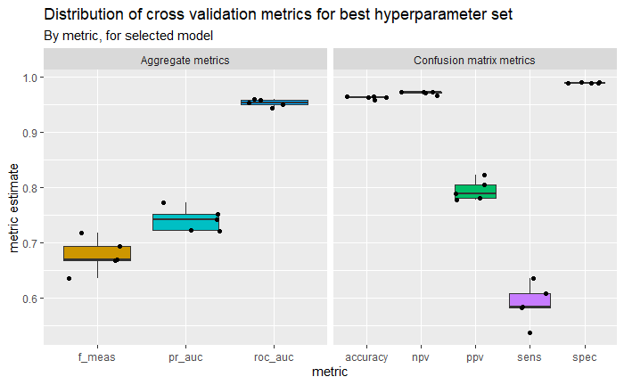

```r
best_glmnet_fold_metrics <- calculate_best_performance_metrics(glmnet_fold_metrics, best_glmnet_params)
```

```r
best_glmnet_fold_metrics %>%
  group_by(.metric) %>%
  summarize(overall_perf = mean(.estimate))
```

|  | .metric | overall_perf |
| --- | --- | --- |
| 1 | accuracy | 0.9617474 |
| 2 | f_meas | 0.6769179 |
| 3 | npv | 0.9706005 |
| 4 | ppv | 0.7946756 |
| 5 | pr_auc | 0.7417206 |
| 6 | roc_auc | 0.9522610 |
| 7 | sens | 0.5898970 |
| 8 | spec | 0.9889096 |

Here we can see the overall performance of the best model during its cross validation phase. This performance mirrors the behavior of the previous cross-validation metrics. The ROC AUC is again looking very stable, while the PR AUC leaves a bit to be desired. The metrics which rely on threshold are very stable and performant for calculations which rely or focus heavily on the class of disinterest. On the other hand, the sensitivity and ppv leave much to be desired. Again, implementing a tailored thresholding strategy here will allow for better use of the model.

# 3 Performance on training data as a whole

## 3.1 ROC Curve

Let’s start by looking at an ROC curve.

```
    === AUCs ===

     Model name Dataset ID Curve type       AUC
   1     Model1          1        ROC 0.9535918
   2     Model1          1        PRC 0.7487327

    === Input data ===

     Model name Dataset ID # of negatives # of positives
   1     Model1          1          31377           2294
```

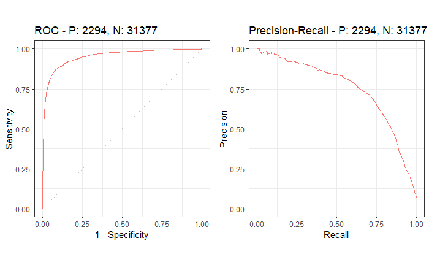

```r
#get prediction class and probabilities
hp_training_preds <- get_prediction_dataframes(glmnet_final_fit, train_data)

plot_performance_curves(hp_training_preds)
```

These are two strongly corner-based curves which is promising.

## 3.2 Interpretating probability thresholds

In this section, we gain insight into what we should do for thresholding and our expectations surrounding it.

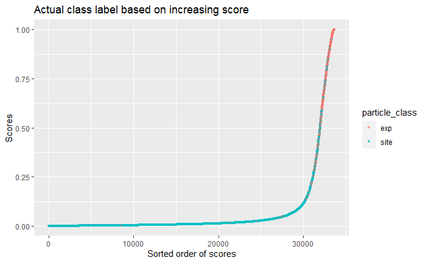

```r
plot_label_by_score(hp_training_preds)
```

### 3.2.2 Calibration curve

In this section, we look at the calibration curve of the model. Calibration curves closer to the 45 degree line demonstrate better calibrated models (e.g., where scores can be interpreted as probabilities).

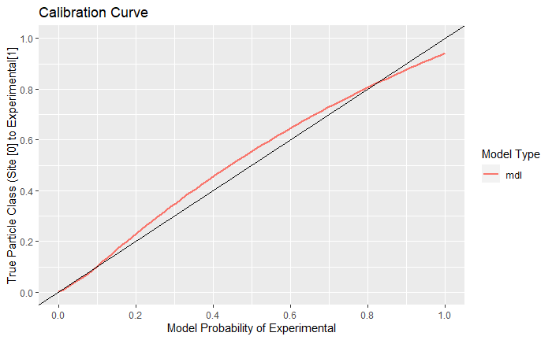

```r
plot_calibration_curve(hp_training_preds)
```

## 3.3 Interpretations based on thresholds

In this section, we look at the threshold that has been chosen for evaluation. Here, this is 0.5.

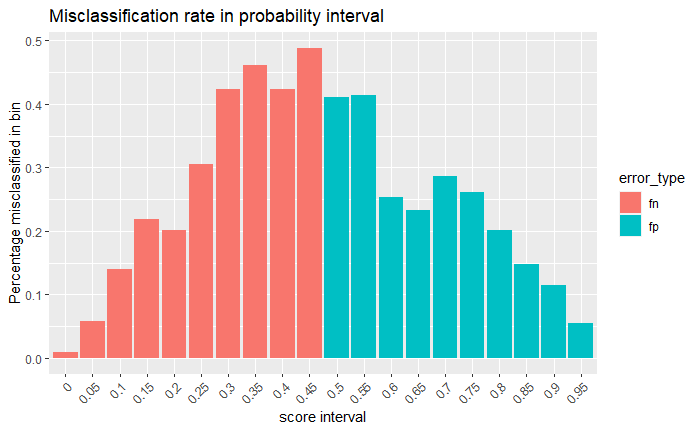

```r
plot_misclassification_rates(hp_training_preds)
```

Here, we see the same sort of information reflected in the first plot, where the misclassification error seems to start heavily around 0.3. In that area, we’re classifying a lot of things negative that we shouldn’t, and flipping things over to 0.5, we start classifying things positive that we shouldn’t.

### 3.3.1 Confusion Matrix

Here, we look at the confusion matrix for the entire training set as well as computations from the confusion matrix.

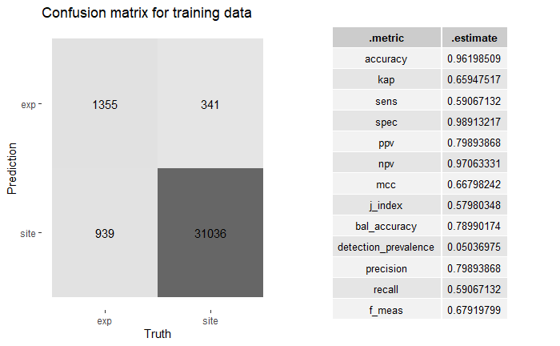

```r
conf_mat <- calculate_confusion_matrix(hp_training_preds)
```

These results allow us several important insights: 1. The confusion matrix reflects the distribution of the data 2. The calculated metrics correctly reflect the target class formulation 3. The performance leaves room for improvement in terms of metrics calculated based on a threshold depending on the objectives of classification.

# 4 Explaining the model

## 4.1 Variable imporance

What parameters are contributing most strongly to the classification? We’ll use permutation importance for this.

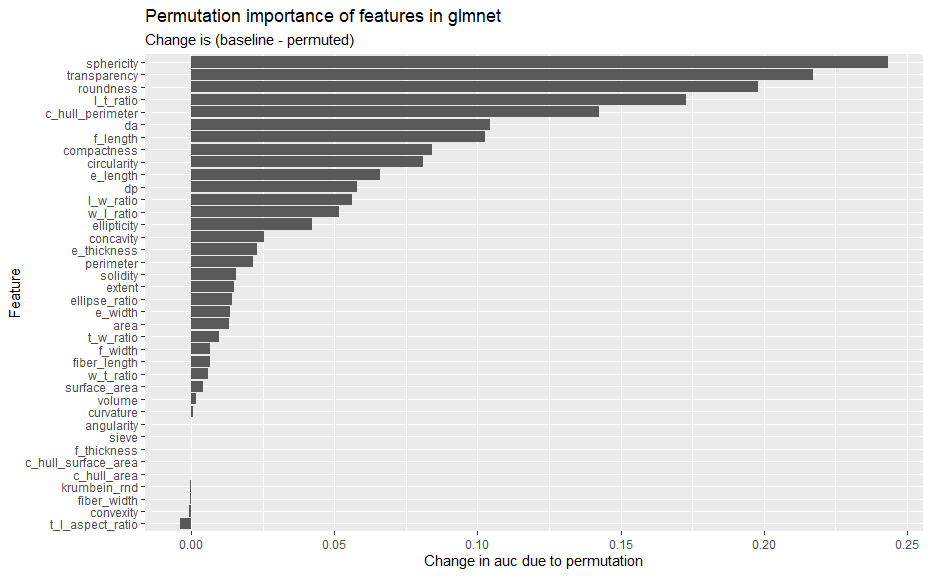

Of previous interest was transparency, solidity, and other metrics for discerning the different classes. Here, we can make several observations:

1. We can see here that the e and f length differentially contribute to discriminating between different particle types. However, I find this curious since one would think these would be essentially the same value (i.e., highly correlated).
2. `da` and `dp` additionally contribute differentially to the classification. The confusion around this result points to previous suggestions regarding restricting the size of the particles in the data. This may also assist with (1).
3. Previous assertions have been confirmed regarding the relation of `transparency`, `compactness`, `solidity`, and other features regarding their relationship with microdebitage.

# 5 Save markdown file

```r
#fs::file_copy('51-glmnet-performance.nb.html', './html_results/51-glmnet-performance.nb.html', overwrite=TRUE)
```